# Introduction to Package EvoGeneX

Soumitra Pal

2022-06-03

EvoGeneX is a package to infer mode of gene expression evolution from expression data.

```r
library(tidyverse)
library(EvoGeneX)
library(png)
library(knitr)
library(ape)
```

# 1 Input to EvoGeneX

In addition to the expression data, EvoGeneX needs 1) a phylogenetic tree, and 2) information about different regimes operating on different parts of the phylogenetic tree.

## 1.1 Phylogenetic tree

The phylogenetic tree should have exactly the set of species for which gene expression data is collected as the leaf nodes. It must have numeric length on the branches abstracting evolutionary time since the root denoting the most recent ancestor of the species under study. It should be specified in Newick format. A copy of the nine-species Drosphila phylogeny used in the EvoGeneX paper is kept at `inst/extdata/drosophila9.newick`.

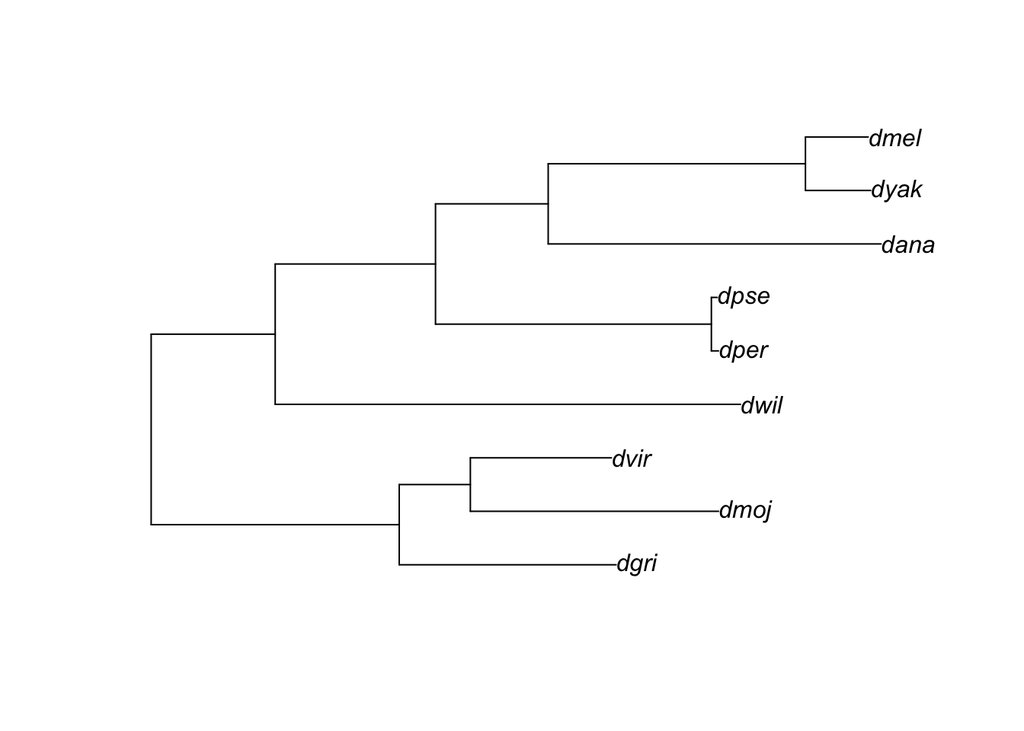

```r
dros9_newick_file <- system.file("extdata", "drosophila9.newick", package = "EvoGeneX")
phylo_tree <- read.tree(dros9_newick_file)
plot(phylo_tree)
```

## 1.2 Regime specification

If EvoGeneX is used to infer about adaptation of expression towards different parts of the phylogenetic tree, it must be specified as a data frame containing three columns each taking string values: 1) `node`, 2) `node2` and 3) `regime` and as many rows as the nodes in the tree including the non-leaf internal nodes. For the leaf nodes, `node` gives species name, `regime` gives a name for the regime and `node2` is kept empty. Each internal node `x` is specified by two leaf species `node` and `node2` such that `x` is the most recent common ancestor of `node` and `node2`. Note that `x` can be specified using different combinations of `node` and `node2`, use any one of them.

If EvoGeneX is used to infer if a gene evolved in a constrained way, not necessarily in an adaptive way, all nodes in the tree are assumed to be in a single regime. Nevertheless, and we need to specify that in a file as given in `inst/extdata/regime_global.csv`.

```r
single_regime_file <- system.file("extdata", "regime_global.csv", package = "EvoGeneX")
single_regime <- read.csv(single_regime_file)
single_regime
```

```
##    node node2 regime
## 1  dmel       global
## 2  dyak       global
## 3  dana       global
## 4  dpse       global
## 5  dper       global
## 6  dwil       global
## 7  dvir       global
## 8  dmoj       global
## 9  dgri       global
## 10 dmel  dyak global
## 11 dmel  dana global
## 12 dpse  dper global
## 13 dmel  dper global
## 14 dmel  dwil global
## 15 dvir  dmoj global
## 16 dvir  dgri global
## 17 dmel  dgri global
```

## 1.3 Expression Data

EvoGeneX needs exactly `nspecies` x `nreplicate` expression values where `nspecies` and `nreplicate` denote the number of species and replicates, respectively. Currently, EvoGeneX does not support missing values of a few replicates of some of the species, which may be supported in a future version. These `nspecies` x `nreplicate` expression values can be provided as a R `data.frame` either in the matrix (`wide`) or vector format (`tall`).

In the `wide` format the `data.frame` must contain a column for the species and the rest of the columns will be treated as replicates. The default name of the species column is `species` though it can be changed through the `species_col` parameter of the `fit` function (see below). There must be exactly `nspecies` number of rows. An example expression data for 9 Drosophila species in 4 replicates is given in `inst/extdata/HD_M_FBgn0000008.csv`.

```r
sample_data_file <- system.file("extdata", "HD_M_FBgn0000008.csv", package = "EvoGeneX")
wide <- read.csv(sample_data_file)
wide
```

```
##   species       R1        R2        R3       R4
## 1    dana 204.5885 148.66722 230.49887 199.3192
## 2    dgri 318.4320 258.96714 240.11517 259.6903
## 3    dmel 241.2408 212.74946 204.11434 190.5641
## 4    dmoj 132.7657  69.73923  65.77837 110.6977
## 5    dper 107.1932 109.08483 124.48701 140.8748
## 6    dpse 245.1403 188.31841 228.28671 211.3906
## 7    dvir 543.9844 696.80922 663.95690 785.1595
## 8    dwil 155.7480 214.93546 282.80718 316.0916
## 9    dyak 106.0654 117.31824 102.06957 108.0820
```

In the `tall` format the `data.frame` must contain at least 3 columns for the species, replicates and expression values and the rest of the columns will simply be ignored. The default name of the 3 columns are `species`, `replicate` and `exprval`, respectively, though they can be changed through the parameters `species_col`, `replicate_col` and `exprval_col`, respectively, of the `fit` function. Note that the parameters `replicate_col` and `exprval_col` are not relevant in `wide` format. There must be exactly `nspecies` x `nreplicate` number of rows in `tall` format. Following code shows the same example expression data in `tall` format.

```r
tall <- wide %>% gather("replicate", "exprval", -species)
tall
```

```
##    species replicate   exprval
## 1     dana        R1 204.58850
## 2     dgri        R1 318.43200
## 3     dmel        R1 241.24080
## 4     dmoj        R1 132.76570
## 5     dper        R1 107.19320
## 6     dpse        R1 245.14030
## 7     dvir        R1 543.98440
## 8     dwil        R1 155.74800
## 9     dyak        R1 106.06540
## 10    dana        R2 148.66722
## 11    dgri        R2 258.96714
## 12    dmel        R2 212.74946
## 13    dmoj        R2  69.73923
## 14    dper        R2 109.08483
```

[output cut: 22 more lines]

# 2 Check gene for constrained expression evolution

Now we show how to infer whether the expression of the gene in the example data evolved neutrally or in a constrained manner. The example script `examples/example_constrained.R` gives the complete code used in this section.

## 2.1 Setup EvoGeneX object with species tree and single-regime

```r
evog <- EvoGeneX()
evog$setTree(dros9_newick_file)
evog$setRegimes(single_regime_file)
```

## 2.2 Fit replicated Ornstein-Uhlenbeck model

```r
ou_res <- evog$fit(wide, alpha = 0.1, gamma = 0.01)
print(ou_res)
```

```
## $optim.diagn
## $optim.diagn$convergence
## [1] 1
##
## $optim.diagn$message
## NULL
##
##
## $theta
##   global
## 247.6608
##
## $alpha
## [1] 13.76675
##
## $sigma.sq
## [1] 785188.3
##
## $gamma
## [1] 0.002799634
##
## $loglik
## [1] -206.8637
```

## 2.3 Fit replicated Brownian Motion model

We decide whether a gene has evolved neutrally or in a constrained manner by fitting the data to both replicated models, Ornstein-Uhlenbeck and Brownian Motion and checking which model is most likely supported by the data. So we fit the data to the replicated Brownian Motion model as well.

```r
brown <- Brown()
brown$setTree(dros9_newick_file)

brown_res <- brown$fit(wide, gamma = 0.01)
print(brown_res)
```

```
## $optim.diagn
## $optim.diagn$convergence
## [1] 1
##
## $optim.diagn$message
## NULL
##
##
## $theta
## [1] 285.5768
##
## $sigma.sq
## [1] 167801.1
##
## $gamma
## [1] 0.01346066
##
## $loglik
## [1] -209.7939
```

## 2.4 Infer constrained or neutral

We use log-likelihood ratio test to check which model most likely support the data. That is implemented by $\chi^2$ test on the test statistics -2 * (log-likelihood in null model - loglikelihood in alternate model)) taking Brownian motion as null and OU as alternate.

```r
# degrees of freedom under different models
ou_dof <- (
  1   # alpha
  + 1 # sigma.sq
  + 1 # theta
  + 1 # gamma
)
brown_dof <- (
  1   # sigma.sq
  + 1 # theta
  + 1 # gamma
)

# loglikelihood ratio test OU VS Brownian motion
pvalue <- 1 - pchisq((ou_res$loglik - brown_res$loglik) * 2,
                     (ou_dof - brown_dof))

constrained_vs_neutral <- ifelse(pvalue < 0.05, "constrained", "neutral")
constrained_vs_neutral
```

```
## [1] "constrained"
```

# 3 Check gene for adpative expression evolution

Now we show how to infer whether the expression of the gene in the example data evolved in an adaptive manner. The example script `examples/example_adaptive.R` gives the complete code used in this section.

## 3.1 Multi-regime

To test if a gene’s expression evolved in an adaptive manner, we need to specify at least two regimes and which of the nodes in the phylogenetic tree including the non-leaf internal nodes belong to each of the regimes. Here we consider a two-regime example where the species in Drosophila and Sophophora sub-genra belong to different regimes.

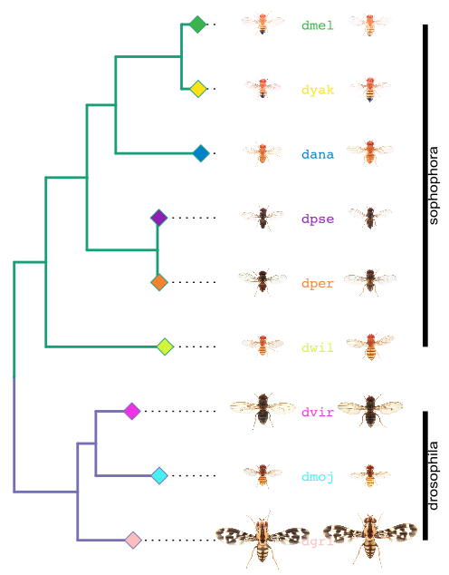

```r
two_regime_image <- system.file("extdata", "phylogeny_two_regime.png", package = "EvoGeneX")
knitr::include_graphics(two_regime_image)
```

```r
two_regime_file <- system.file("extdata", "regime_tworegime.csv", package = "EvoGeneX")
two_regime <- read.csv(two_regime_file)
two_regime
```

```
##    node node2     regime
## 1  dmel       sophophora
## 2  dyak       sophophora
## 3  dana       sophophora
## 4  dpse       sophophora
## 5  dper       sophophora
## 6  dwil       sophophora
## 7  dvir       drosophila
## 8  dmoj       drosophila
## 9  dgri       drosophila
## 10 dmel  dyak sophophora
## 11 dmel  dana sophophora
## 12 dpse  dper sophophora
## 13 dmel  dper sophophora
## 14 dmel  dwil sophophora
## 15 dvir  dmoj drosophila
## 16 dvir  dgri drosophila
## 17 dmel  dgri sophophora
```

## 3.2 Fit data and infer adaptive evolution

Like constrained case, we call a gene adaptive if both the neutral Bownian Motion model and constrained model (OU with a single optimum expression) are rejected in favor of adaptive evolution model (OU with multiple optima).

```r
evog2 <- EvoGeneX()
evog2$setTree(dros9_newick_file)
evog2$setRegimes(two_regime_file)

ou2_res <- evog$fit(wide, alpha = 0.1, gamma = 0.01)
print(ou2_res)
```

```
## $optim.diagn
## $optim.diagn$convergence
## [1] 1
##
## $optim.diagn$message
## NULL
##
##
## $theta
##   global
## 247.6608
##
## $alpha
## [1] 13.76675
##
## $sigma.sq
## [1] 785188.3
##
## $gamma
## [1] 0.002799634
##
## $loglik
## [1] -206.8637
```

```r
# degrees of freedom under different models
ou2_dof <- (
  1   # alpha
  + 1 # sigma.sq
  + 2 # theta
  + 1 # gamma
)

# loglikelihood ratio test OU2 VS replicated Brownian Motion
ou2_vs_bm_pvalue <- 1 - pchisq((ou2_res$loglik - brown_res$loglik) * 2,
                               (ou2_dof - brown_dof))

# loglikelihood ratio test OU2 VS OU
ou2_vs_ou_pvalue <- 1 - pchisq((ou2_res$loglik - ou_res$loglik) * 2,
                               (ou2_dof - ou_dof))

# gene is adaptive if both OU2vsBM and OU2vsOU tests are successfull
is_adaptive <- ifelse(max(ou2_vs_bm_pvalue, ou2_vs_ou_pvalue) < 0.05,
                      "adaptive", "not-adaptive")

is_adaptive
```

```
## [1] "not-adaptive"
```

# 4 Drosophila datasets

In the main paper for EvoGeneX, we apply EvoGeneX to replicated gene expression (bulk RNA-seq) data from 5 different body-parts of both sexes from 9 Drosophila species. The EvoGeneX package includes this Drosophila data which can be accessed using function.

```r
# Describe the data in the package
data(package="EvoGeneX")
```

```r
# Access one example body-part sample
data(FemaleHead, package = "EvoGeneX")
head(FemaleHead)
```

```
##      FBgnDmel SymbolDmel F_HD_dmel_R1 F_HD_dmel_R2 F_HD_dmel_R3 F_HD_dmel_R4
## 1 FBgn0000008          a  213.7328471    195.40689  203.6376820     224.4284
## 2 FBgn0000014      abd-A    0.0000000      0.00000    0.8970823       0.0000
## 3 FBgn0000015      Abd-B    0.6399187      0.00000    0.4485411       0.0000
## 4 FBgn0000017        Abl 1114.6018054   1023.84673 1020.2657126     867.4850
## 5 FBgn0000018        abo   72.3108136     65.82127   61.8986787      68.1024
## 6 FBgn0000022         ac    0.0000000      0.00000    0.0000000       0.0000
##   F_HD_dyak_R1 F_HD_dyak_R2 F_HD_dyak_R3 F_HD_dyak_R4 F_HD_dana_R1 F_HD_dana_R2
## 1    83.264808     83.28962   106.178657     86.97742    192.11953     182.5986
## 2     0.000000      0.00000     0.000000      0.00000      0.00000       0.0000
## 3     1.460786      0.00000     1.106028      0.00000      0.00000       0.0000
## 4   679.265541    672.09424   569.972931    430.40372    516.16113     486.0537
## 5    45.284369     35.62677    30.968775     17.03681     38.42391      60.4283
## 6     0.000000      0.00000     0.000000      0.00000      0.00000       0.0000
##   F_HD_dana_R3 F_HD_dana_R4 F_HD_dpse_R1 F_HD_dpse_R2 F_HD_dpse_R3 F_HD_dpse_R4
```

[output cut: 34 more lines]

# 5 Repeat for multiple genes

Here we show how we can check multiple genes for constrained expression evolution using Drosophila dataset. Similar can be done for adaptive evolution.

```r
# take 5 genes from FemaleHead dataset
df <- FemaleHead[1:5,]

# setup EvoGeneX object
evog <- EvoGeneX()
evog$setTree(dros9_newick_file)
evog$setRegimes(single_regime_file)

# setup Brown object
brown <- Brown()
brown$setTree(dros9_newick_file)

# degrees of freedom under different models
ou_dof <- (
  1   # alpha
  + 1 # sigma.sq
  + 1 # theta
  + 1 # gamma
)
brown_dof <- (
  1   # sigma.sq
  + 1 # theta
  + 1 # gamma
)

fdr_cutoff <- 0.05

process_single_gene <- function(data_wide) {
  # process single gene
  # all 36 expression values are in a single row
  # need convert it to either 'wide' or 'tall' format
  # we convert into 'tall' format
  data_tall <- (
    data_wide
    %>% gather("sample", "exprval")
    %>% separate(sample,  c("sex", "tissue", "species", "replicate"))
    %>% select("species", "replicate", "exprval")
  )

  ou_res <- evog$fit(data_tall, format = "tall", alpha = 0.1, gamma = 0.01)
  brown_res <- brown$fit(data_tall, format = "tall", gamma = 0.01)

  # loglikelihood ratio test EvoGeneX VS replicated Brownian motion
  pvalue <- 1 - pchisq((ou_res$loglik - brown_res$loglik) * 2,
                       (ou_dof - brown_dof))
}

res <- (
  df
  %>% group_by(FBgnDmel, SymbolDmel)
  %>% summarize(pvalue = process_single_gene(cur_data()), .groups = "keep")
  %>% ungroup()
  %>% mutate(qvalue = p.adjust(pvalue, method = "fdr"))
  %>% mutate(constrained_vs_neutral = ifelse(qvalue < fdr_cutoff,
                                              "constrained", "neutral"))
)
```

# 6 Citation

```r
citation("EvoGeneX")
```

```
##
##
##   Soumitra Pal, Brian C. Oliver, and Teresa M. Przytycka. Modeling gene
##   expression evolution with EvoGeneX uncovers differences in evolution
##   of species, organs and sexes. bioRxiv (2021): 2020-01.
##   <10.1101/2020.01.06.895615>.
##
## A BibTeX entry for LaTeX users is
##
##   @Article{,
##     title = {Stochastic modeling of gene expression evolution uncovers tissue and sex specific properties of expression evolution in the Drosophila genus},
##     author = {Soumitra  Pal and Brian C. Oliver and Teresa M. Przytycka},
##     journal = {Journal of Computational Biology},
##     year = {2022},
##     volume = {xx},
##     number = {yy},
##     pages = {ppp},
##     doi = {10.1101/2020.01.06.895615},
##   }
```